# Roosting

Realized I was going down a rabbit hole with the VRI and decided to focus on going down a different rabbit hole. Here’s my plan of attack:

- Select points taken during the night. These are presumably points when the bird was roosing.
- Do some kind of cluster analysis to locate clusters of points. One cluster per night should indicate where the bird slept that night.
- Generate a centroid point for each cluster.
- (Maybe) do some recusion analysis to see if the bird often returns to the same place to roost or not.
- Prep data for RSF.
- Do the RSF thing to see what kind of forest NOGO like to roost in. Working from the assumption that NOGO only roost in forest, I can look at:
  - Forest age
  - Forest density
  - Dominant tree spp
  - Distance to edge - though this is challenging bc some cut blocks are misIDd

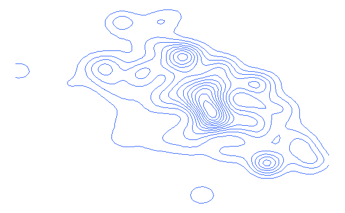

As usual, I can’t show the actual points, but this gives the idea. The next step is to separate out the nighttime points.

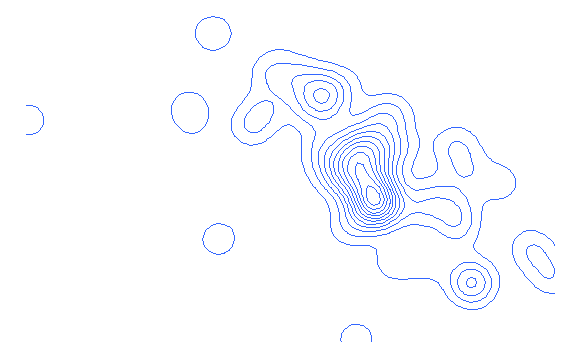

[figure not shown]